# What is the problem?

[figure not shown]

As you saw, there are alot of companies around the world whose data is currently publicly available on the internet. This data is very sensitive and can be used to harm the company.

Our goal is to understand cyber threats that prioritize the safety and security of our customer's sensitive information, which can help build trust and confidence in cybersecurity companies' services.

[figure not shown]

Our client, Saluslab, is a security company that has developed a tool to protect networks and companies from potential attackers.

# Data Sources

[figure not shown]

# Let's explore the data!

[figure not shown]

As we saw, the attckers mostly target the companies with middle revenue more that highest ones, this is perhaps is because companies with high revenue have more security protocols and are more difficult to attack, also the companies with very low revenue are not worth the effort as they are less likely to pay anyway.

[figure not shown]

A surprising fact is that the attackers mostly target the companies in the Construction industry, although their data might not be as critical as other industries like Health care for example. this might be because the construction companies are less likely to have a good security system. or because the number of companies in this industry is very high, usually.

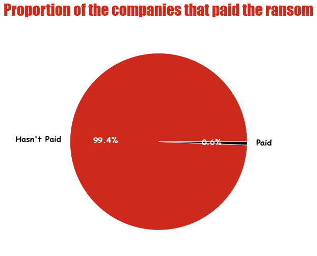

Based on our available data, we have observed that only a small number of companies that paid the ransom are represented in our dataset. As a result, we are unable to fully support the insights we extracted regarding the distribution of industries. This limitation is due to the crawling frequency of our system, as well as the fact that it has been running stably for only one week.

# Predictive analysis

# 1- What is the probability of a company being attacked?

# Logistic Regression

[figure not shown]

- Note that the test data was totally new to the model as it came from a completely different source *gang website* from that of the training data.
- Ragardless of the source of the testing data, the model always performed well.

## Insightful Interpretation

[figure not shown]

- From the coefficients values shown in the above table, we can see that `revenue`, `employee_range` and industry sre the most affecting features, and that behaviour is the same for all gangs.

# 2- Which gang is most probable to attack?

# Random Forest Classifier

```
Classification report:
              precision    recall  f1-score   support

         0.0       0.00      0.00      0.00        26
         1.0       0.00      0.00      0.00        16
         2.0       0.16      0.10      0.12        31
         3.0       0.45      0.30      0.36        30
         4.0       0.32      0.27      0.29        44
         5.0       0.51      0.76      0.61       117

    accuracy                           0.43       264
   macro avg       0.24      0.24      0.23       264
weighted avg       0.35      0.43      0.37       264
```

- The results are very bad, but this is not surprising as we showed in the previous predictive analysis that the gangs are very similar and currently we don't have enough data to distinguish between them.
- This is one of the limitations due to crawling, and we consider it as a future work.

# Inferential Insights

Given that companies in the USA rank among the companies most vulnerable to attacks, are small companies in Europe vulnerable to attacks?

- By applying Chi-Square test:

|  | USA | Europe |
| --- | --- | --- |
| attacked | 339 | 154 |
| not attacked | 263 | 55 |

- The **p-value** is *1.3632153665534083e-05 <.05* which proves that there is a relationship between the two variables.